# ESM 206 Fall 2019 Lab 8

Allison Horst

11/14/2019

In lectures during week 8, we’ll learning about:

- Comparisons of means between > 2 groups by one-way Analysis of Variance (ANOVA) with post-hoc Tukey’s HSD
- Chi-square test for independence (comparing proportions across groups)

### Lab 8 Objectives:

- Compare mean across > 2 groups by one-way ANOVA (`aov`)
- Perform post-hoc Tukey’s HSD (`TukeyHSD`)
- Create a ggplot2 graph with error bars
- Chi-square test for association with `chisq.test()`
- Make a table of proportions with `janitor::adorn_*` + `kable`

### One-way ANOVA

We’ll be comparing sizes for three penguin species (Gentoo, Chinstrap and Adelie) collected by researchers at [Palmer Station LTER, Antarctica](https://pal.lternet.edu/).

Illustrated comparison from the [British Antarctic Survey](https://www.bas.ac.uk/about/antarctica/wildlife/penguins/):

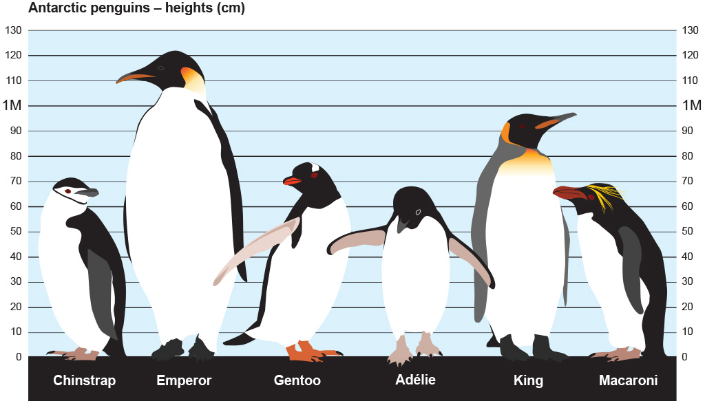

### 1. Read in the *penguins.csv* dataset

```r
penguins <- readr::read_csv("penguins.csv") %>%
  janitor::clean_names()
```

### 2. Make a table of counts by species and sex

```r
penguin_counts <- penguins %>%
  count(species, sex)

penguin_counts
```

```
## # A tibble: 9 x 3
##   species                                   sex        n
##   <chr>                                     <chr>  <int>
## 1 Adelie Penguin (Pygoscelis adeliae)       FEMALE    73
## 2 Adelie Penguin (Pygoscelis adeliae)       MALE      73
## 3 Adelie Penguin (Pygoscelis adeliae)       <NA>       6
## 4 Chinstrap penguin (Pygoscelis antarctica) FEMALE    34
## 5 Chinstrap penguin (Pygoscelis antarctica) MALE      34
## 6 Gentoo penguin (Pygoscelis papua)         .          1
## 7 Gentoo penguin (Pygoscelis papua)         FEMALE    58
## 8 Gentoo penguin (Pygoscelis papua)         MALE      61
## 9 Gentoo penguin (Pygoscelis papua)         <NA>       4
```

We ask: Is there a significant difference in mean flipper length (mm) between the three species for **female** penguins?

- Null hypothesis: There is no significant difference in mean flipper length between the three groups
- Alternative hypothesis: There **is** a significant difference in mean flipper length between the three groups

### 3. First, look at the distributions for female penguin flipper lengths

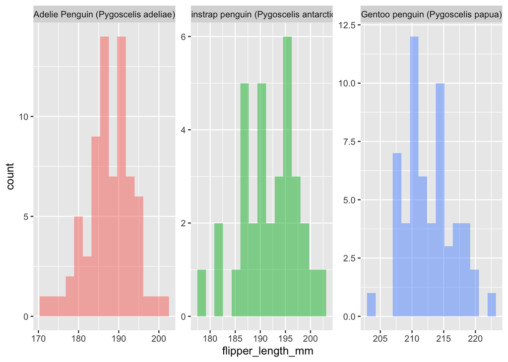

```r
penguin_f <- penguins %>%
  filter(sex == "FEMALE")

# Faceted histograms:
ggplot(data = penguin_f, aes(x = flipper_length_mm)) +
  geom_histogram(aes(fill = species),
                 alpha = 0.5,
                 show.legend = FALSE,
                 bins = 15) +
  facet_wrap(~species, scales = "free")
```

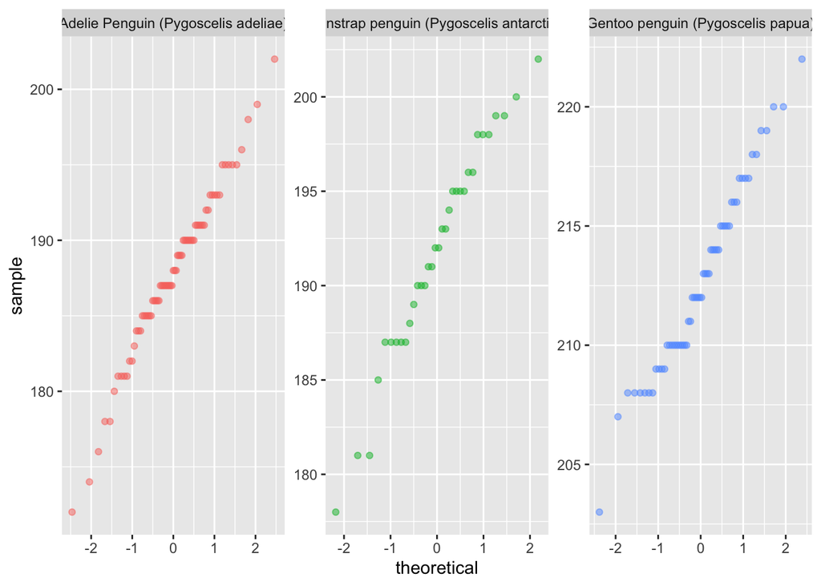

```r
# Faceted QQ plots:
ggplot(data = penguin_f, aes(sample = flipper_length_mm)) +
  geom_qq(aes(color = species),
                 alpha = 0.5,
                 show.legend = FALSE
          ) +
  facet_wrap(~species, scales = "free")
```

```r
# These look pretty darn normal. Let's see what their means, sds, se, and variances are:
```

### 4. Find summary statistics, check for equal variances

```r
penguin_f_summary <- penguin_f %>%
  group_by(species) %>%
  summarize(
    mean_flipper_length = mean(flipper_length_mm),
    sd_flipper_length = sd(flipper_length_mm),
    sample_size = n(),
    se_flipper_length = sd(flipper_length_mm) / sqrt(n()),
    var_flipper_length = var(flipper_length_mm)
  )

penguin_f_summary
```

```
## # A tibble: 3 x 6
##   species mean_flipper_le… sd_flipper_leng… sample_size se_flipper_leng…
##   <chr>              <dbl>            <dbl>       <int>            <dbl>
## 1 Adelie…             188.             5.60          73            0.655
## 2 Chinst…             192.             5.75          34            0.987
## 3 Gentoo…             213.             3.90          58            0.512
## # … with 1 more variable: var_flipper_length <dbl>
```

```r
# Importantly, variances are pretty close (largest is < 4x greater than the smallest)
# But we can perform a Levene's Test for equal variances anyway:

leveneTest(flipper_length_mm ~ species, data = penguin_f) # Not significant (we retain the null hypothesis of equal variances)
```

```
## Levene's Test for Homogeneity of Variance (center = median)
##        Df F value  Pr(>F)
## group   2  2.9012 0.05782 .
##       162
## ---
## Signif. codes:  0 '***' 0.001 '**' 0.01 '*' 0.05 '.' 0.1 ' ' 1
```

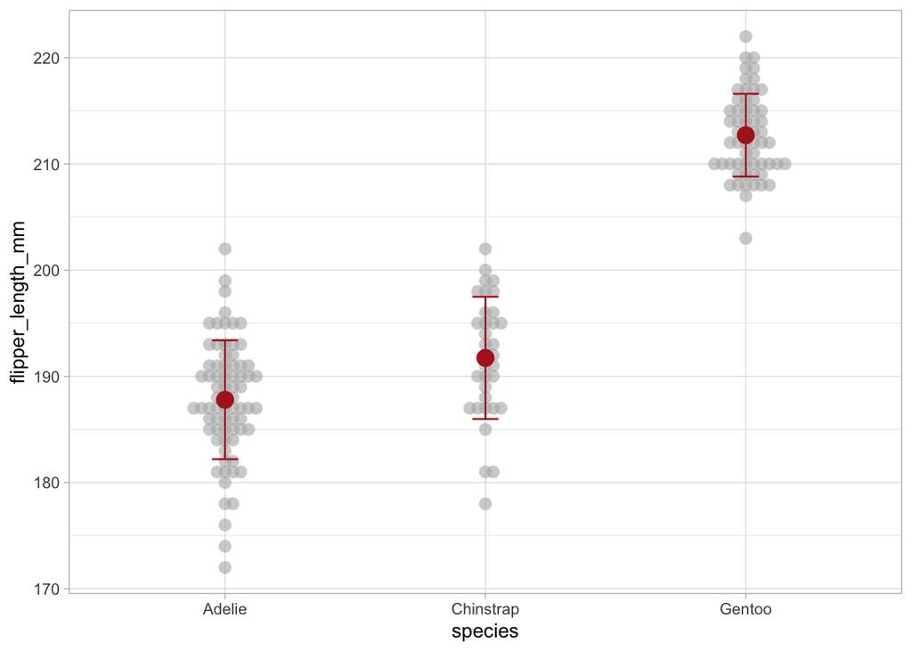

```r
ggplot() +
  geom_beeswarm(data = penguin_f,
                aes(x = species,
                    y = flipper_length_mm,
                    ),
                size = 3,
                alpha = 0.6,
                pch = 16,
                color = "gray70") +
  scale_x_discrete(labels = c("Adelie", "Chinstrap", "Gentoo")) +
  geom_point(data = penguin_f_summary, aes(x = species, y = mean_flipper_length),
             color = "firebrick",
             size = 4) +
  geom_errorbar(data = penguin_f_summary,
                aes(x = species,
                    ymin = mean_flipper_length - sd_flipper_length,
                    ymax = mean_flipper_length + sd_flipper_length),
                color = "firebrick",
                width = 0.1) +
  theme_light()
```

### 6. One-way ANOVA

Use `aov()` for one-way (single factor) ANOVA in R:

```r
penguin_aov <- aov(flipper_length_mm ~ species, data = penguin_f)
summary(penguin_aov)
```

```
##              Df Sum Sq Mean Sq F value Pr(>F)
## species       2  21416   10708   411.8 <2e-16 ***
## Residuals   162   4213      26
## ---
## Signif. codes:  0 '***' 0.001 '**' 0.01 '*' 0.05 '.' 0.1 ' ' 1
```

```r
# We retain the alternative hypothesis (mean flipper lengths for the 3 species are NOT the same). But are they all different from each other? Or just two?
```

```r
penguin_lm <- lm(flipper_length_mm ~ species, data = penguin_f)
penguin_aov_t3 <- Anova(penguin_lm)
penguin_aov_t3
```

```
## Anova Table (Type II tests)
##
## Response: flipper_length_mm
##            Sum Sq  Df F value    Pr(>F)
## species   21415.6   2  411.79 < 2.2e-16 ***
## Residuals  4212.6 162
## ---
## Signif. codes:  0 '***' 0.001 '**' 0.01 '*' 0.05 '.' 0.1 ' ' 1
```

```r
# Notice that the F statistic value here (411.79) is almost exactly the same - the difference between these two is minimal.
```

### 7. Post-hoc Tukey’s HSD

```r
TukeyHSD(penguin_aov)
```

```
##   Tukey multiple comparisons of means
##     95% family-wise confidence level
##
## Fit: aov(formula = flipper_length_mm ~ species, data = penguin_f)
##
## $species
##                                                                                    diff
## Chinstrap penguin (Pygoscelis antarctica)-Adelie Penguin (Pygoscelis adeliae)  3.940774
## Gentoo penguin (Pygoscelis papua)-Adelie Penguin (Pygoscelis adeliae)         24.912376
## Gentoo penguin (Pygoscelis papua)-Chinstrap penguin (Pygoscelis antarctica)   20.971602
##                                                                                     lwr
## Chinstrap penguin (Pygoscelis antarctica)-Adelie Penguin (Pygoscelis adeliae)  1.436275
## Gentoo penguin (Pygoscelis papua)-Adelie Penguin (Pygoscelis adeliae)         22.790647
## Gentoo penguin (Pygoscelis papua)-Chinstrap penguin (Pygoscelis antarctica)   18.366227
##                                                                                     upr
## Chinstrap penguin (Pygoscelis antarctica)-Adelie Penguin (Pygoscelis adeliae)  6.445272
## Gentoo penguin (Pygoscelis papua)-Adelie Penguin (Pygoscelis adeliae)         27.034105
## Gentoo penguin (Pygoscelis papua)-Chinstrap penguin (Pygoscelis antarctica)   23.576977
##                                                                                   p adj
## Chinstrap penguin (Pygoscelis antarctica)-Adelie Penguin (Pygoscelis adeliae) 0.0007922
## Gentoo penguin (Pygoscelis papua)-Adelie Penguin (Pygoscelis adeliae)         0.0000000
## Gentoo penguin (Pygoscelis papua)-Chinstrap penguin (Pygoscelis antarctica)   0.0000000
```

```r
# Conclusion: means for ALL pairwise combinations are significantly different
```

### 8. Chi-Square test for independence

Chi-square is a test for associations between two or more nominal (categorical variables), usually comparing counts within groups across levels.

What we’re really asking: are the proportions within different levels in a group so different *across* multiple groups that we actually think there’s an effect of *group*?

**Null hypothesis**: There is no significant association between Variable A and Variable B (or, Variables A and B are independent)

**Alternative hypothesis**: There IS a significant association between Variable A and Variable B (or, Variables A and B are NOT independent)

Explore the `gss_cat` built-in dataset from forcats package (sample from the General Social survey, 2000 - 2014): `View(gss_cat)`

First, let’s filter this a bit:

First, filter then get a table of counts & proportions:

```r
# Get the counts:
party_relig <- gss_cat %>%
  filter(partyid %in% c("Strong republican", "Strong democrat")) %>%
  filter(relig %in% c("None", "Catholic")) %>%
  count(partyid, relig)

# Put it into wide format (contingency table):
party_relig_table <- party_relig %>%
  pivot_wider(names_from = relig, values_from = n)
```

#### Make a nice table with proportions using janitor::adorn_*

Once again, `janitor` just being totally awesome:

```r
party_relig_props <- party_relig_table %>%
  janitor::adorn_percentages(denominator = "row") %>%
  adorn_pct_formatting(digits = 0) %>%
  adorn_ns(position = "front")

party_relig_props <- party_relig_props %>%
  rename(Affiliation = partyid)

party_relig_props
```

```
##        Affiliation      None  Catholic
##  Strong republican 117 (20%) 481 (80%)
##    Strong democrat 554 (43%) 720 (57%)
```

A nicer version of this table:

```r
kable(party_relig_props) %>%
  kable_styling()
```

| Affiliation | None | Catholic |
| --- | --- | --- |
| Strong republican | 117 (20%) | 481 (80%) |
| Strong democrat | 554 (43%) | 720 (57%) |

Whoooaaaa thanks again, `janitor`!!!

Now, we’ll ask: Are political and religious affiliation independent?

#### Chi-square test for independence

A. First, get just a contingency table of counts we just want the four count values in a df, nothing else:

```r
chi_counts <- party_relig_table %>%
  select(-partyid)

chi_counts
```

```
## # A tibble: 2 x 2
##    None Catholic
##   <int>    <int>
## 1   117      481
## 2   554      720
```

B. Run a chi-square test for independence using `chisq.test()`:

```r
my_party_chi <- chisq.test(chi_counts)

my_party_chi
```

```
##
##  Pearson's Chi-squared test with Yates' continuity correction
##
## data:  chi_counts
## X-squared = 100.22, df = 1, p-value < 2.2e-16
```

Result: Party and religious affiliation are NOT independent.

Another way of saying that: There is a significant difference in religious affiliation (none or Catholic) for Strong Republicans and Strong Democrats.

Another way of saying that: There is a significant association between party and religious affiliation for the levels studied.

#### Let’s do another example with independents and strong democrats:

```r
# Get the counts:
party_relig_2 <- gss_cat %>%
  filter(partyid %in% c("Independent", "Strong democrat")) %>%
  filter(relig %in% c("None", "Catholic")) %>%
  count(partyid, relig)

# Put it into wide format (contingency table):
party_relig_table_2 <- party_relig_2 %>%
  pivot_wider(names_from = relig, values_from = n)

party_relig_props_2 <- party_relig_table_2 %>%
  janitor::adorn_percentages(denominator = "row") %>%
  adorn_pct_formatting(digits = 0) %>%
  adorn_ns(position = "front")

party_relig_props_2 <- party_relig_props_2 %>%
  rename(Affiliation = partyid)

party_relig_props_2
```

```
##      Affiliation      None   Catholic
##      Independent 984 (48%) 1045 (52%)
##  Strong democrat 554 (43%)  720 (57%)
```

Are these significantly different? They look pretty close. Are they different enough (given the large sample sizes) to detect a significant difference?

```r
chi_counts_2 <- party_relig_table_2 %>%
  select(-partyid)

chi_counts_2
```

```
## # A tibble: 2 x 2
##    None Catholic
##   <int>    <int>
## 1   984     1045
## 2   554      720
```

```r
# Run chi-square:
chisq.test(chi_counts_2) # Still significantly different, but it's important to show the ACTUAL PROPORTIONS, which are pretty close!!!
```

```
##
##  Pearson's Chi-squared test with Yates' continuity correction
##
## data:  chi_counts_2
## X-squared = 7.6999, df = 1, p-value = 0.005522
```